# Fundamental Analysis - MGM Resorts International

[figure not shown]

| Buffet's [check list](https://www.process.st/checklist/warren-buffets-investment-checklist/#record-basic-details): |
| --- |

1. Is the business simple and understandable?
2. Does the business have a consistent operating history?
3. Does the business have favourable long-term prospects?
4. Is management candid with the shareholders?
5. Does management resist the institutional imperative?
6. Is the focus on Return On Equity?
7. What is the rate of "owner earnings"?
8. Is there a high profit margin?
9. Has the company created at least one dollar of market value, for every dollar retained?
10. What is the value of the business?
11. Can it be purchased at a significant discount to its value?

## 1. Is the business simple and understandable (background)

- MGM Resorts operates integrated casino, hotel, and entertainment resorts across the United States and in Macau
- They are well positioned to take adavantage of legalization of sports betting [(link)](https://seekingalpha.com/article/4314958-top-stocks-to-buy-sports-betting-is-legalized)
- They have about one fourth of all units in the Las Vegas
- They have a significant amount of indebtedness maturing in 2022
- They are required to pay a significant portion of our cash flows as rent.
- They rely heavily on the ability of our resorts to generate operating cash flow to fund capital expenditures, provide excess cash flow for future development, acquisitions or investments, and repay debt financings.
- The results of operations do not tend to be seasonal in nature as all of our casino resorts operate 24 hours a day
- Holder assets tilsvarende aksje verdien
- They face significant competition with respect to destination travel locations generally and with respect to our peers in the industries in which we compete.
- The business is particularly sensitive to reductions in discretionary consumer spending and corporate spending on conventions, trade shows and business development.

## 2. Does the business have a consistent operating history?

```python
# Some necessary import:
import pandas as pd
import numpy as np
import matplotlib.pyplot as plt
%matplotlib inline
%config InlineBackend.figure_format = 'retina'
plt.style.use('fivethirtyeight')
import time
import datetime
import os
import FundamentalAnalysis as fa
import config
import myFunctions
ticker = "MGM"
api_key = config.apiKey
```

```python
income_statement_annually = fa.income_statement(ticker, api_key, period="annual")
```

```python
income = income_statement_annually[income_statement_annually.index == 'netIncome'].T
income.head(7).style.format('${0:,.2f}')
```

|  | netIncome |
| --- | --- |
| 2019 | $2,049,146,000.00 |
| 2018 | $466,772,000.00 |
| 2017 | $1,960,286,000.00 |
| 2016 | $1,101,440,000.00 |
| 2015 | $-447,720,000.00 |
| 2014 | $-149,873,000.00 |
| 2013 | $-156,606,000.00 |

### Comments:

- They have some disconcerning years with losses. However, 2015 for example is due to: WIn 2015, we recorded non-cash impairment charges of $1.5 billion to reduce the historical carrying value of goodwill related to the MGM China reporting unit"
- Hence, they likely overpaid for their assets in China.
- Let us veryify that the cash flows are positive:

```python
cash_flow_statement_annually = fa.cash_flow_statement(ticker, api_key, period="annual")
```

```python
cf = cash_flow_statement_annually[cash_flow_statement_annually.index == 'freeCashFlow'].T
cf.head().style.format('${0:,.2f}')
```

|  | freeCashFlow |
| --- | --- |
| 2019 | $1,071,395,000.00 |
| 2018 | $235,696,000.00 |
| 2017 | $342,329,000.00 |
| 2016 | $-728,501,000.00 |
| 2015 | $-483,740,000.00 |

The 2015 annual repot states that there was a decrease in revenue in China due to stricter regulations. Hence, I consider this to be a one time occurrence.

## 3. Does the business have favourable long-term prospects?

I consider it likely that revenue will normalize in the following year, and that valuation will come back to normal. However, travel might be restricted in the future and online gambling is also a significant threat.

```python
key_metrics_annually = fa.key_metrics(ticker, api_key, period="annual")
array = ['peRatio', 'pbRatio', 'debtToAssets', 'dividendYield' , 'roe']
key_metrics_annually[key_metrics_annually.index.isin(array)]
```

|  | 2019 | 2018 | 2017 | 2016 | 2015 | 2014 | 2013 | 2012 | 2011 | 2010 | 2009 | 2008 | 2007 | 2006 | 2005 | 2004 | 2003 | 2002 | 2001 |
| --- | --- | --- | --- | --- | --- | --- | --- | --- | --- | --- | --- | --- | --- | --- | --- | --- | --- | --- | --- |
| peRatio | 8.006562 | 33.802144 | 10.833271 | 15.015235 | -24.347561 | -63.802319 | -75.384894 | -3.477180 | 2.063089 | NaN | -3.060244 | -2.632723 | 14.557377 | 30.0000 | 23.987179 | 15.129722 | 12.729635 | 6.891892 | 14.728972 |
| pbRatio | 2.123211 | 2.422790 | 2.789607 | 2.658827 | 2.129110 | 2.337433 | 2.790174 | 1.407974 | 1.055728 | NaN | 1.021297 | 0.566564 | 3.805662 | 5.0520 | 3.286623 | 2.250770 | 1.224323 | 0.756502 | 0.996216 |
| debtToAssets | 0.771898 | 0.784438 | 0.738928 | 0.779217 | 0.796951 | 0.846797 | 0.837949 | 0.833913 | 0.780792 | 0.000000 | 0.000000 | 0.000000 | 0.000000 | 0.0000 | 0.000000 | 0.000000 | 0.000000 | 0.000000 | 0.000000 |
| dividendYield | 0.016535 | 0.016516 | 0.011867 | 0.006250 | 0.028184 | 0.040441 | 0.026966 | 0.033646 | NaN | NaN | NaN | NaN | NaN | NaN | NaN | NaN | NaN | NaN | NaN |
| roe | 0.265184 | 0.071676 | 0.257504 | 0.177075 | -0.087447 | -0.036636 | -0.037012 | -0.404918 | 0.511722 | -0.479365 | -0.333731 | -0.215201 | 0.261425 | 0.1684 | 0.137016 | 0.148765 | 0.096179 | 0.109767 | 0.067637 |

```python
# The high debt to assets ratio is worrying.
```

### Competitiors:

```python
# Caesars Entertainment Corporation (CZR)
key_metrics_annually = fa.key_metrics('CZR', api_key, period="annual")
array = ['peRatio', 'pbRatio', 'debtToAssets', 'dividendYield' , 'roe']
key_metrics_annually[key_metrics_annually.index.isin(array)]
```

|  | 2019 | 2018 | 2017 | 2016 | 2015 | 2014 | 2013 | 2012 |
| --- | --- | --- | --- | --- | --- | --- | --- | --- |
| peRatio | -7.800870 | 20.285677 | -10.304400 | -0.362034 | 0.169738 | -0.551739 | -0.931280 | -0.655259 |
| pbRatio | 4.374491 | 1.891249 | 1.198186 | -0.406704 | 1.018085 | -0.307282 | -0.879436 | -2.383410 |
| debtToAssets | 0.915920 | 0.873909 | 0.873589 | 1.213307 | 0.919065 | 1.212322 | 1.126454 | 1.014705 |
| dividendYield | NaN | NaN | NaN | NaN | NaN | NaN | NaN | NaN |
| roe | -0.560770 | 0.093231 | -0.116279 | 1.123387 | 5.997974 | 0.556934 | 0.944331 | 3.637357 |

```python
# Las Vegas Sands Corp. (LVS)
key_metrics_annually = fa.key_metrics('LVS', api_key, period="annual")
array = ['peRatio', 'pbRatio', 'debtToAssets', 'dividendYield' , 'roe']
key_metrics_annually[key_metrics_annually.index.isin(array)]
```

|  | 2019 | 2018 | 2017 | 2016 | 2015 | 2014 | 2013 | 2012 | 2011 | 2010 | 2009 | 2008 | 2007 | 2006 | 2005 |
| --- | --- | --- | --- | --- | --- | --- | --- | --- | --- | --- | --- | --- | --- | --- | --- |
| peRatio | 18.917791 | 19.221658 | 22.122937 | 25.135329 | 18.276058 | 15.429447 | 27.781489 | 27.280330 | NaN | NaN | -27.609942 | -12.347159 | 254.928335 | 64.227804 | 62.308975 |
| pbRatio | 9.840023 | 8.160074 | 9.560598 | 6.795532 | 5.271587 | 6.075942 | 8.357456 | 5.887665 | NaN | NaN | 1.564755 | 0.456677 | 13.160828 | 17.533323 | 10.982148 |
| debtToAssets | 0.776413 | 0.747904 | 0.686131 | 0.698227 | 0.675199 | 0.677413 | 0.662674 | 0.681377 | 0.575656 | 0.599200 | 0.642651 | 0.723497 | 0.802881 | 0.708810 | 0.585143 |
| dividendYield | 0.058777 | 0.064228 | 0.047409 | 0.069302 | 0.074937 | 0.054453 | 0.024414 | 0.082792 | NaN | NaN | 0.009301 | -0.003394 | NaN | NaN | 0.001191 |
| roe | 0.520147 | 0.424525 | 0.432158 | 0.270358 | 0.288442 | 0.393789 | 0.300828 | 0.215821 | 0.239867 | 0.117305 | -0.056674 | -0.036986 | 0.051626 | 0.272986 | 0.176253 |

```python
# Hilton Worldwide Holdings
key_metrics_annually = fa.key_metrics('HLT', api_key, period="annual")
array = ['peRatio', 'pbRatio', 'debtToAssets', 'dividendYield' , 'roe']
key_metrics_annually[key_metrics_annually.index.isin(array)]
```

|  | 2019 | 2018 | 2017 | 2016 | 2015 | 2014 | 2013 |
| --- | --- | --- | --- | --- | --- | --- | --- |
| peRatio | 35.527687 | 29.302696 | 22.237363 | 54.871149 | 25.668305 | 77.995022 | 34.892555 |
| pbRatio | -65.306081 | 40.630236 | 13.511988 | 3.237016 | 6.021437 | 11.046012 | 3.318911 |
| debtToAssets | 1.031557 | 0.960629 | 0.855186 | 0.774942 | 0.767266 | 0.818105 | 0.839018 |
| dividendYield | 0.005464 | 0.008085 | 0.006965 | 0.014506 | 0.003829 | NaN | NaN |
| roe | -1.838174 | 1.386570 | 0.607625 | 0.058993 | 0.234586 | 0.141625 | 0.095118 |

### Price comparision

```python
start =  int(time.mktime(datetime.date(2000,1,1).timetuple()))
end =  int(time.mktime(datetime.date(2020,6,30).timetuple()))

# List of assets:
links =[]
ticker_list = []

# MGM Resorts International (MGM)
ticker_list.append('MGM')
# Caesars Entertainment Corporation (CZR)
ticker_list.append('CZR')
# Las Vegas Sands Corp. (LVS)
ticker_list.append('LVS')
# Hilton Worldwide Holdings Inc. (HLT)
ticker_list.append('HLT')

for ticker in ticker_list:
    links.append(myFunctions.yahooLink(start, end, ticker))

# Pulling data or loading if already pulled:
df_full = pd.DataFrame()

if os.path.isfile('./data/tourismAnalysis.pkl'):
    df_full = pd.read_pickle("./data/tourismAnalysis.pkl")
else:
    for idx, link in enumerate(links):
        print(idx, link)
        df_temp = pd.read_csv(link)
        df_temp['ticker'] = ticker_list[idx]
        df_full = df_full.append(df_temp)
    df_full.to_pickle("./data/tourismAnalysis.pkl")
```

```python
data = df_full[['Date', 'ticker', 'Adj Close']]
data.columns = ['date', 'ticker', 'adj_close']
data = data.drop_duplicates(keep = 'first')
# Displaying data
df = data.set_index('date')
table = df.pivot(columns='ticker')
#table.columns =  ['Bonds', 'Agriculture', 'Emerging', 'Europe', 'Japan', 'US', 'China', 'Gold', 'Oil'] #table.columns = [col[1] for col in table.columns]
table = table.dropna()
#table.head()
```

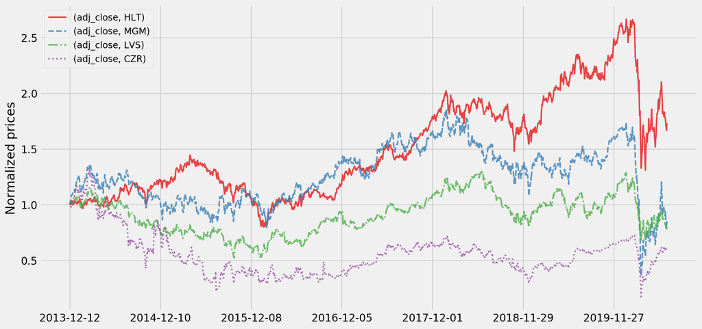

```python
returns = np.log(table) - np.log(table.shift(1))
table_norm = table / table.iloc[0,:] # Normalize values to start at 1
ax = plt.gca()
palette = plt.get_cmap('Set1')

styles = ['-', '--', '-.', ':']

for idx, series in enumerate(returns.mean().sort_values(ascending = False).index):
    table_norm[series].plot(figsize=(14, 7), lw=2, alpha=0.8, color=palette(idx), style = styles[idx % 4], ax=ax)
plt.legend(loc='upper left', fontsize=12)
plt.xlabel("")
plt.ylabel('Normalized prices')
```

## 4. Is management candid with the shareholders?

#### 4.2 How Likely Is It To Meet Future Obligations?

According to the balance sheet below, they have a big war chest of cash to sustain the current crisis. Also major debt repayments are only due in 2022. Debt covenants mainly limit the companies ability to take on additional debt and pay dividends. Debt covenants does not seem to be a major risk.

#### 4.3 How Good A Job Are The Managers Doing?

William J. (Bill) Hornbuckle IV is President of MGM Resorts International, headquartered in Paradise, Nevada.He took a pay cut during the current crisis. He has lots of experience in the industry, and there seem to be no scandals associated with him.

```python
balance_sheet_quarterly = fa.balance_sheet_statement(ticker, api_key, period="quarter")
```

```python
quarterList = balance_sheet_quarterly.columns.to_list()[0:5]
balance_sheet_quarterly[quarterList].iloc[3:33,:].style.format('${0:,.0f}')
```

|  | 2020-03 | 2019-12 | 2019-09 | 2019-06 | 2019-03 |
| --- | --- | --- | --- | --- | --- |
| cashAndCashEquivalents | $6,016,417,000 | $2,329,604,000 | $1,233,569,000 | $1,160,591,000 | $1,223,404,000 |
| shortTermInvestments | $1,596,170,000 | $822,366,000 | $758,992,000 | $746,733,000 | $730,996,000 |
| cashAndShortTermInvestments | $6,016,417,000 | $2,329,604,000 | $1,233,569,000 | $1,160,591,000 | $1,223,404,000 |
| netReceivables | $454,826,000 | $612,717,000 | $550,345,000 | $562,772,000 | $602,602,000 |
| inventory | $106,327,000 | $102,888,000 | $104,206,000 | $106,707,000 | $111,302,000 |
| otherCurrentAssets | $1,020,359,000 | $962,484,000 | $992,626,000 | $209,964,000 | $269,827,000 |
| totalCurrentAssets | $7,597,929,000 | $4,007,693,000 | $2,880,746,000 | $2,040,034,000 | $2,207,135,000 |
| propertyPlantEquipmentNet | $15,172,959,000 | $18,285,955,000 | $20,603,978,000 | $21,054,337,000 | $21,196,438,000 |
| goodwill | $2,091,595,000 | $2,084,564,000 | $2,076,431,000 | $2,080,904,000 | $2,001,646,000 |
| intangibleAssets | $3,795,850,000 | $3,826,504,000 | $3,866,536,000 | $3,922,684,000 | $4,046,756,000 |
| goodwillAndIntangibleAssets | $5,887,445,000 | $5,911,068,000 | $5,942,967,000 | $6,003,588,000 | $6,048,402,000 |
| longTermInvestments | $1,596,170,000 | $822,366,000 | $758,992,000 | $0 | $0 |
| taxAssets | $44,459,000 | $27,167,000 | $23,877,000 | $20,994,000 | $18,536,000 |
| otherNonCurrentAssets | $8,819,943,000 | $4,822,107,000 | $958,311,000 | $1,694,762,000 | $1,676,410,000 |
| totalNonCurrentAssets | $31,520,976,000 | $29,868,663,000 | $28,288,125,000 | $28,773,681,000 | $28,939,786,000 |
| otherAssets | $0 | $0 | $0 | $0 | $0 |
| totalAssets | $39,118,905,000 | $33,876,356,000 | $31,168,871,000 | $30,813,715,000 | $31,146,921,000 |
| accountPayables | $202,735,000 | $235,437,000 | $253,637,000 | $277,591,000 | $336,586,000 |
| shortTermDebt | $1,538,857,000 | $0 | $0 | $0 | $2,548,000 |
| taxPayables | $0 | $218,027,000 | $0 | $0 | $0 |
| deferredRevenue | $2,388,072,000 | $126,966,000 | $125,518,000 | $120,978,000 | $119,033,000 |
| otherCurrentLiabilities | $884,655,000 | $2,610,993,000 | $2,914,089,000 | $2,387,970,000 | $2,354,511,000 |
| totalCurrentLiabilities | $2,626,247,000 | $3,191,423,000 | $3,293,244,000 | $2,786,539,000 | $2,812,678,000 |
| longTermDebt | $11,743,348,000 | $11,168,904,000 | $14,943,874,000 | $14,661,695,000 | $14,730,829,000 |
| deferredRevenueNonCurrent | $0 | $0 | $0 | $0 | $0 |
| deferredTaxLiabilitiesNonCurrent | $2,388,072,000 | $2,106,506,000 | $1,536,426,000 | $1,552,552,000 | $1,566,931,000 |
| otherNonCurrentLiabilities | $0 | $0 | $0 | $0 | $0 |
| totalNonCurrentLiabilities | $14,131,420,000 | $13,275,410,000 | $16,480,300,000 | $16,214,247,000 | $16,297,760,000 |
| otherLiabilities | $14,187,324,000 | $9,682,258,000 | $5,334,775,000 | $5,292,445,000 | $5,250,279,000 |
| totalLiabilities | $30,944,991,000 | $26,149,091,000 | $25,108,319,000 | $24,293,231,000 | $24,360,717,000 |

## 5. Does management resist the institutional imperative?

5.1. An institution resists any change in its current direction

5.2. Just as work expands to fill available time, corporate projects or acquisitions will materialize to soak up available funds

5.3. Any business craving of the leader, however foolish, will quickly be supported by detailed rate-of-return and strategic studies prepared by his troops

5.4.The behaviour of peer companies, whether they are expanding, acquiring, setting executive compensation or whatever, will be mindlessly imitated

Their strategy is to increase Profit Growth Plan under the “one company, one culture” vision.

- MGM 2020 will be a company-wide, business optimization initiative aimed to leverage a more centralized organization to maximize profitability and, through key investments in technology, lay the groundwork for the company’s digital transformation to drive revenue growth.
- MGM Resorts is generating significant free cash flow. Over the next few years, the company expects to reallocate a portion of its annual capital expenditure budget to specific technology advancements that will increase revenues and grow market share by innovating and elevating the guest experience through data, pricing, digital and loyalty capabilities and optimizing business mix [(source)](https://www.hotelbusiness.com/mgm-resorts-unveils-strategic-plan-for-future-growth/).

It seems to be focusing on increasing revenue from existing assets, which seems like reasonable strategy. They also seek to turn a set of gaming assets into a powerful entertainment brand

## 6. Is the focus on Return On Equity?

Accoring to 5. the Company seems to have a helthy mix between growth and earnings

## 8. Is there a high profit margin?

```python
income_statement_quarterly = fa.income_statement(ticker, api_key, period="quarter")
```

```python
profitMargin = income_statement_quarterly[income_statement_quarterly.index == 'grossProfitRatio']
profitMargin.T.head()
```

|  | grossProfitRatio |
| --- | --- |
| 2020-03 | 0.72094 |
| 2019-12 | 0.71193 |
| 2019-09 | 0.723868 |
| 2019-06 | 0.724379 |
| 2019-03 | 0.715838 |

## 9. Has the company created at least one dollar of market value, for every dollar retained?

I am not sure how to quickly calculate this one.

## 10. What is the value of the business?

```python
dcf_annually = fa.discounted_cash_flow(ticker, api_key, period="annual")
```

```python
dcf_annually
```

|  | 2020 | 2019 | 2018 | 2017 | 2016 | 2015 | 2014 | 2013 | 2012 | 2011 | 2010 | 2009 |
| --- | --- | --- | --- | --- | --- | --- | --- | --- | --- | --- | --- | --- |
| date | 2020-07-22 | 2019-12-31 | 2018-12-31 | 2017-12-31 | 2016-12-31 | 2015-12-31 | 2014-12-31 | 2013-12-31 | 2012-12-31 | 2011-12-31 | 2010-12-31 | 2009-12-31 |
| Stock Price | 16.69 | 31.3 | 28.99 | 37.11 | 29.11 | 20.08 | 19.48 | 24.11 | 12.57 | 13.15 | 14.49 | 11.06 |
| DCF | 21.1051 | 35.7443 | 31.7952 | 39.7312 | 31.6562 | 23.1568 | 22.9711 | 27.7935 | 15.7265 | 16.9685 | 0 | 15.7203 |

This is their DCF value on different points in time (they use a WACC method without giving further detail)

## 11. Can it be purchased at a significant discount to its value?